# Ames housing

This is my first [R Markdown](http://rmarkdown.rstudio.com) Notebook. I am going to visualize and analyze the Ames housing dataset. The purpose of this notebook is to predict the final price of a house while having 79 variables for it, which describe almost every aspect of a house.

First thing I do is to import all the libraries I am going to work with.

```r
library(DataExplorer)
library(xgboost)
library(data.table)
library(mltools)
library(glmnet)
```

At this point the most important thing is to check for missing values of both datasets, so let’s read our data and start with train set.

```r
train <- read.csv(file="/home/liofagos/Desktop/Kaggle/Ames housing/train.csv", header=TRUE)
test <- read.csv(file="/home/liofagos/Desktop/Kaggle/Ames housing/test.csv", header=TRUE)
```

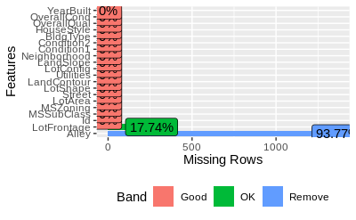

```r
plot_missing(train[,1:20])
```

Test dataset has one column less than the train dataset which is the SalePrice that we will try to predict. To combine them we have to add another column with 0s to our test set so we can work on them. The following two commands do this job for us.

```r
test$SalePrice<-c(rep(0,1459))
train<-rbind(train,test)
```

Our new trainset contains our old train and test set and now we can start working on it. Let’s check our first columns.

```r
head(train)
```

|  | Id | MSSubClass | MSZoning | LotFrontage | LotArea | Street | Alley | LotShape | LandContour | Utilities | LotConfig | LandSlope | Neighborhood | Condition1 | Condition2 | BldgType | HouseStyle | OverallQual | OverallCond | YearBuilt | YearRemodAdd | RoofStyle | RoofMatl | Exterior1st | Exterior2nd | MasVnrType | MasVnrArea | ExterQual | ExterCond | … |
| --- | --- | --- | --- | --- | --- | --- | --- | --- | --- | --- | --- | --- | --- | --- | --- | --- | --- | --- | --- | --- | --- | --- | --- | --- | --- | --- | --- | --- | --- | --- |
| 1 | 1 | 60 | RL | 65 | 8450 | Pave | NA | Reg | Lvl | AllPub | Inside | Gtl | CollgCr | Norm | Norm | 1Fam | 2Story | 7 | 5 | 2003 | 2003 | Gable | CompShg | VinylSd | VinylSd | BrkFace | 196 | Gd | TA | … |
| 2 | 2 | 20 | RL | 80 | 9600 | Pave | NA | Reg | Lvl | AllPub | FR2 | Gtl | Veenker | Feedr | Norm | 1Fam | 1Story | 6 | 8 | 1976 | 1976 | Gable | CompShg | MetalSd | MetalSd | None | 0 | TA | TA | … |
| 3 | 3 | 60 | RL | 68 | 11250 | Pave | NA | IR1 | Lvl | AllPub | Inside | Gtl | CollgCr | Norm | Norm | 1Fam | 2Story | 7 | 5 | 2001 | 2002 | Gable | CompShg | VinylSd | VinylSd | BrkFace | 162 | Gd | TA | … |
| 4 | 4 | 70 | RL | 60 | 9550 | Pave | NA | IR1 | Lvl | AllPub | Corner | Gtl | Crawfor | Norm | Norm | 1Fam | 2Story | 7 | 5 | 1915 | 1970 | Gable | CompShg | Wd Sdng | Wd Shng | None | 0 | TA | TA | … |
| 5 | 5 | 60 | RL | 84 | 14260 | Pave | NA | IR1 | Lvl | AllPub | FR2 | Gtl | NoRidge | Norm | Norm | 1Fam | 2Story | 8 | 5 | 2000 | 2000 | Gable | CompShg | VinylSd | VinylSd | BrkFace | 350 | Gd | TA | … |
| 6 | 6 | 50 | RL | 85 | 14115 | Pave | NA | IR1 | Lvl | AllPub | Inside | Gtl | Mitchel | Norm | Norm | 1Fam | 1.5Fin | 5 | 5 | 1993 | 1995 | Gable | CompShg | VinylSd | VinylSd | None | 0 | TA | TA | … |